# WilloughbyHW1

Bryant Willoughby

2025-09-10

# Problem 1 Instructions

The dataset `teengamb` concerns a study of teenage gambling in Britain. After you install R and the `faraway` package, you can load the faraway package and teengamb data.

1. Make a numerical and graphical summary of the data, commenting on any features that you find interesting. For the variable “sex”, assign the label “male” and “female” and ask R to treat it as a categorical variable before you compute the summary.

Solution to this question should be no longer than 1.5 pages.

2. In your summary, report the means and medians of variables “income” and “gamble”. Please comment on the relative locations of their means and medians, and explain why the means are larger than the medians.
3. How many different values are there for the variable “verbal”? (hint: help(unique)) Based on the boxplot (and any other ways you can define and explain) of the variable “verbal”, what could be the possible values of outlying verbal scores?
4. Suppose you are interested in how variables, such as “verbal”, “income” and “gamble” differ for different ”sex”. Use numerical and/or graphical tool(s) to summarize the data for this purpose, commenting on any features that you find interesting. Limit the output you present to a quantity that a busy reader would find sufficient to get a basic understanding of your answer.

Hints: Some useful R functions for this homework can be found in the course documents that are available on Canvas. You can always type help(subject) to get detailed help on the subject, e.g. help(plot). Or you can type help.start() to get interactive help with a search engine.

## Problem 1: Data loading and factor variable

```r
# Load faraway package and teengamb data
library(faraway)
data(teengamb)

# Create factor variable for sex with labels
teengamb$sex <- factor(teengamb$sex, levels = c(0, 1), labels = c("male", "female"))
str(teengamb)  # Check structure
```

```
## 'data.frame':    47 obs. of  5 variables:
##  $ sex   : Factor w/ 2 levels "male","female": 2 2 2 2 2 2 2 2 2 2 ...
##  $ status: int  51 28 37 28 65 61 28 27 43 18 ...
##  $ income: num  2 2.5 2 7 2 3.47 5.5 6.42 2 6 ...
##  $ verbal: int  8 8 6 4 8 6 7 5 6 7 ...
##  $ gamble: num  0 0 0 7.3 19.6 0.1 1.45 6.6 1.7 0.1 ...
```

# (1) Numerical and graphical summary

```r
# Numerical summary for numeric variables
summary(teengamb[c("status", "income", "verbal", "gamble")])
```

```
##      status          income           verbal          gamble
##  Min.   :18.00   Min.   : 0.600   Min.   : 1.00   Min.   :  0.0
##  1st Qu.:28.00   1st Qu.: 2.000   1st Qu.: 6.00   1st Qu.:  1.1
##  Median :43.00   Median : 3.250   Median : 7.00   Median :  6.0
##  Mean   :45.23   Mean   : 4.642   Mean   : 6.66   Mean   : 19.3
##  3rd Qu.:61.50   3rd Qu.: 6.210   3rd Qu.: 8.00   3rd Qu.: 19.4
##  Max.   :75.00   Max.   :15.000   Max.   :10.00   Max.   :156.0
```

```r
# Frequency table for sex
table(teengamb$sex)
```

```
##
##   male female
##     28     19
```

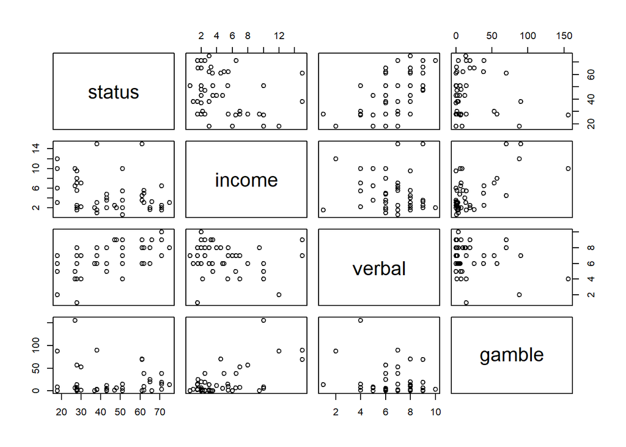

```r
# Pairs plot for numeric variables
pairs(teengamb[c("status", "income", "verbal", "gamble")])
```

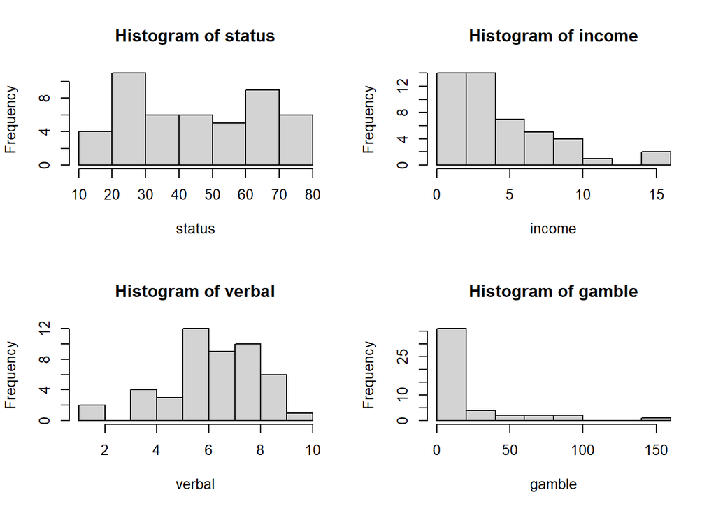

```r
# Histograms for numeric variables
par(mfrow = c(2, 2))  # Layout for 4 variables
for (v in c("status", "income", "verbal", "gamble")) {
  hist(teengamb[[v]], main = paste("Histogram of", v), xlab = v)
}
```

```r
par(mfrow = c(1, 1))  # Reset layout
```

# (2) Means and medians of income and gamble

The respective mean and median for `income` and `gamble`variables are provided below. Notice that the mean is pulled towards the right skewness, whereas the median measure is not influenced by this skewness and is therefore smaller in comparison.

```r
# Means and medians of income and gamble with descriptive labels
paste("Mean income:", mean(teengamb$income))
```

```
## [1] "Mean income: 4.64191489361702"
```

```r
paste("Median income:", median(teengamb$income))
```

```
## [1] "Median income: 3.25"
```

```r
paste("Mean gamble:", mean(teengamb$gamble))
```

```
## [1] "Mean gamble: 19.3010638297872"
```

```r
paste("Median gamble:", median(teengamb$gamble))
```

```
## [1] "Median gamble: 6"
```

# (3) Unique values and boxplot for verbal

There are nine unique values for the `verbal` variable. The two possible outlying verbal scores are one and two, as illustrated in the below boxplot.

```r
# Number of unique values for verbal
length(unique(teengamb$verbal))
```

```
## [1] 9
```

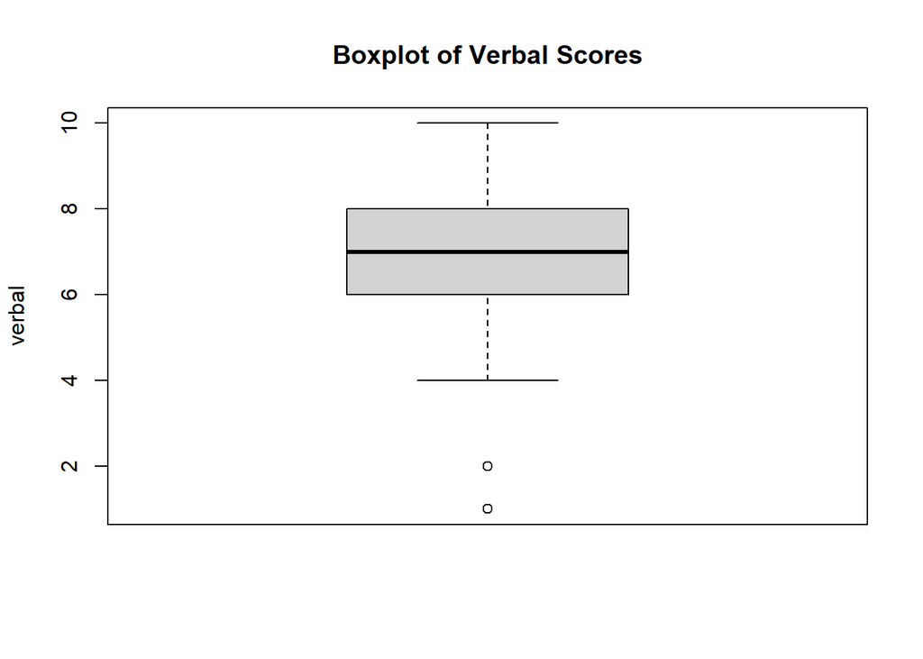

```r
# Boxplot for verbal
boxplot(teengamb$verbal, main = "Boxplot of Verbal Scores", ylab = "verbal")
```

# (4) Compare verbal, income, and gamble by sex

```r
# Numerical summaries of verbal scores by sex
print("Summary of verbal scores by sex:")
```

```
## [1] "Summary of verbal scores by sex:"
```

```r
tapply(teengamb$verbal, teengamb$sex, summary)
```

```
## $male
##    Min. 1st Qu.  Median    Mean 3rd Qu.    Max.
##   1.000   6.000   7.000   6.821   8.250  10.000
##
## $female
##    Min. 1st Qu.  Median    Mean 3rd Qu.    Max.
##   4.000   6.000   6.000   6.421   8.000   8.000
```

```r
# Numerical summaries of income by sex
print("Summary of income by sex:")
```

```
## [1] "Summary of income by sex:"
```

```r
tapply(teengamb$income, teengamb$sex, summary)
```

```
## $male
##    Min. 1st Qu.  Median    Mean 3rd Qu.    Max.
##   0.600   2.000   3.375   4.976   6.625  15.000
##
## $female
##    Min. 1st Qu.  Median    Mean 3rd Qu.    Max.
##   1.500   2.000   3.000   4.149   5.750  10.000
```

```r
# Numerical summaries of gambling expenditure by sex
print("Summary of gambling expenditure by sex:")
```

```
## [1] "Summary of gambling expenditure by sex:"
```

```r
tapply(teengamb$gamble, teengamb$sex, summary)
```

```
## $male
##    Min. 1st Qu.  Median    Mean 3rd Qu.    Max.
##   0.000   2.775  14.250  29.775  42.175 156.000
##
## $female
##    Min. 1st Qu.  Median    Mean 3rd Qu.    Max.
##   0.000   0.100   1.700   3.866   6.000  19.600
```

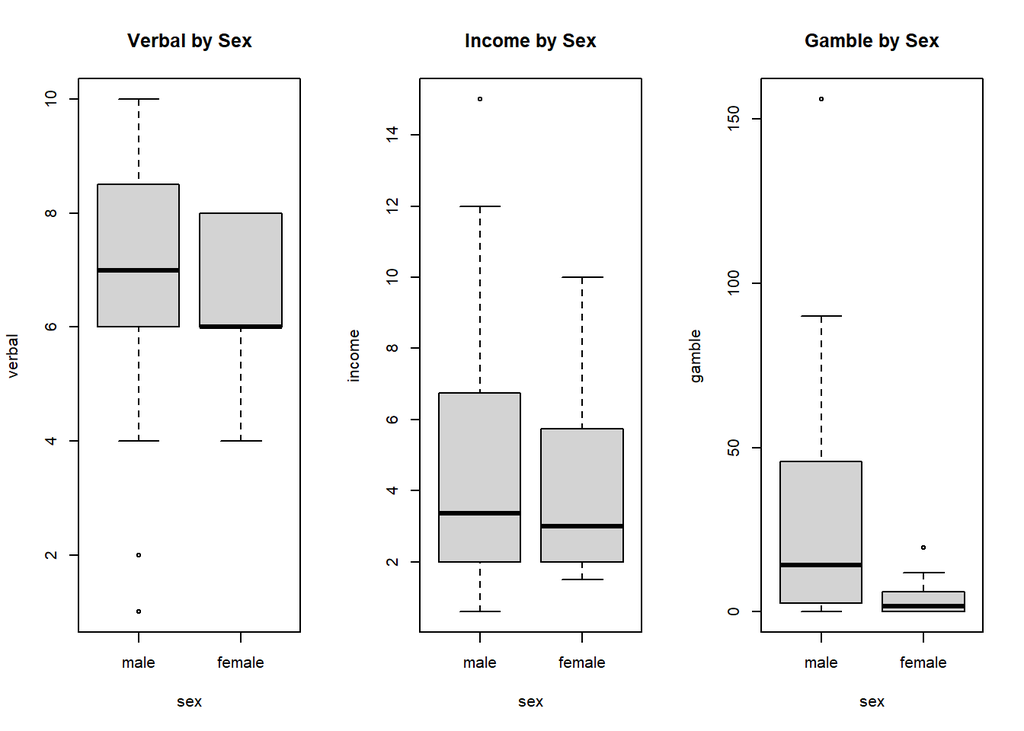

```r
# Boxplots by sex
par(mfrow = c(1, 3))
boxplot(verbal ~ sex, data = teengamb, main = "Verbal by Sex")
boxplot(income ~ sex, data = teengamb, main = "Income by Sex")
boxplot(gamble ~ sex, data = teengamb, main = "Gamble by Sex")
```

```r
par(mfrow = c(1, 1))
```

# Problem 2

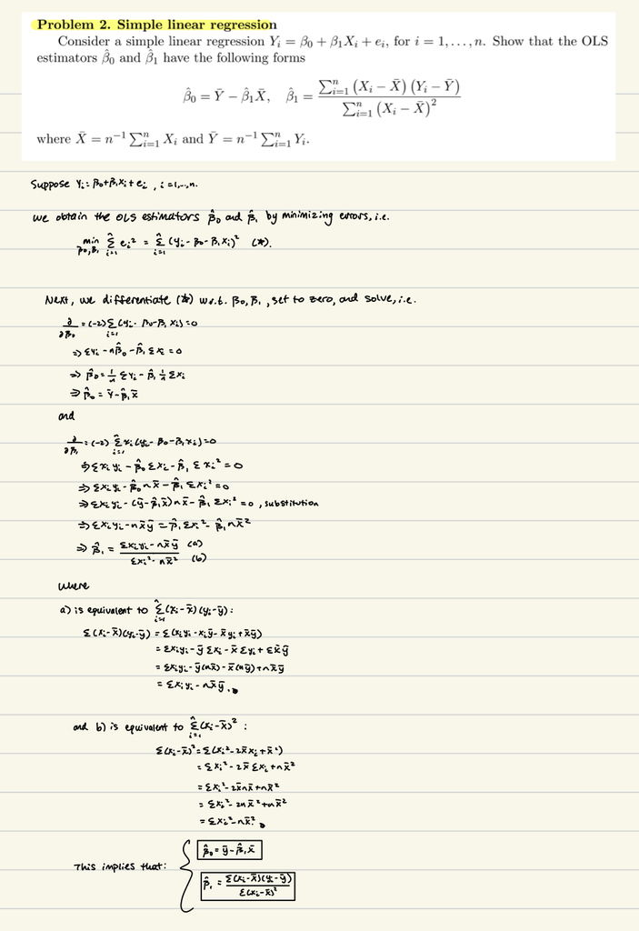

Problem 2 Solution

# Problem 3

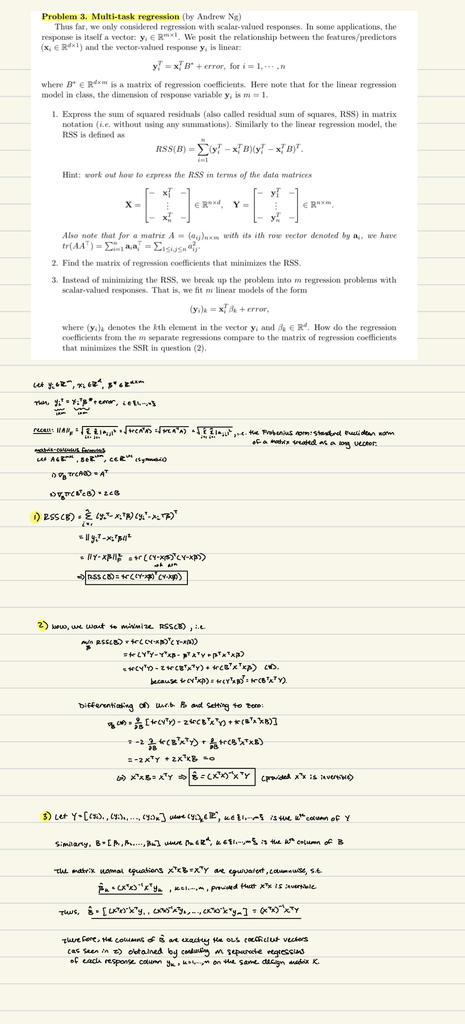

Problem 3 Solution